# (Dataset Exploration Title)

### Relationship between ages and Duration Minutes

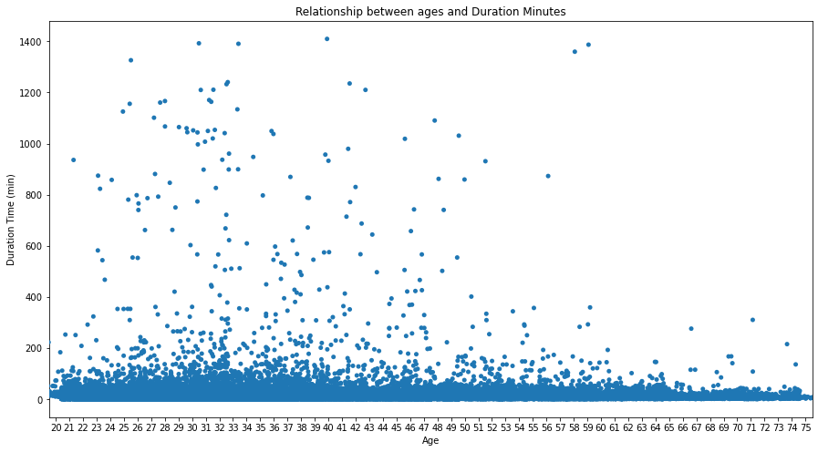

**Note: the scatter plot shows that the most users that have long duration time are between 20 and 50. The younger bikers tend to ride for higher duration so it's a negative relation**

### Relationship between gender and age

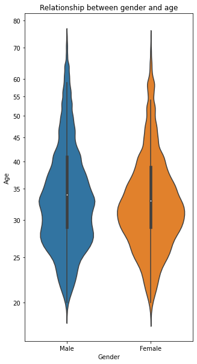

**Note: The male users are older than the female users. The female age distribution is close to male age distribution, but male have more values above 55 years.**

> The duration time of the trips is longer among the young users than old users. This also can be the reason why the duration of the trips is longer for the female riders since the female users are younger than the males' users. This relation between weekdays and hours shows that in the working days starting hours is between 8:00 AM and 9:00 AM and between 5:00 PM and 6:00 Pm, differ from weekend days so users use the bikes to go to work and most of the users are subscribers and most of them are males. customer and subscribers ages are close, same median but the subscribers are slightly older, and customers have a longer duration than subscribers and that's because the majority is riding for fun not going to work

> it's interesting to see that customers have longer duration trips in average than the subscribers while the median age is the same.

## Multivariate Exploration

[figure not shown]

**Note: The plot shows that subscribers ride much shorter trips than customers on each day.**

### Relationship between Start hours, Weekdays and User Types

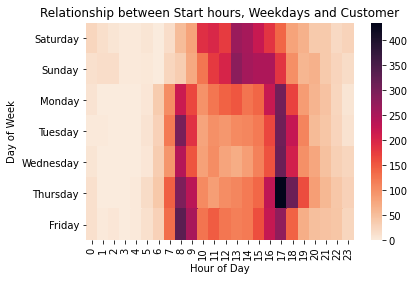

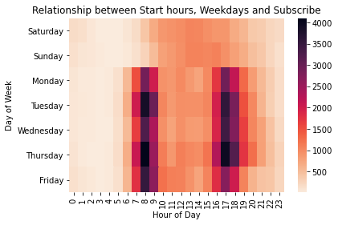

**Note: The heatmaps shows that Subscribers use the system more on work days from Monday to Friday but customers ride a lot on weekends(saturday & sunday). most of trips started between 8:00 & 9:00 Am and between 5:00 & 6:00 Pm on work days for subscribers when used for work.**

> The multivariate exploration shows that subscribers use bikes primarily for going to work, unlike customers, they're taking advantage of the bike sharing system quite differently from the subscribers, heavily over weekends, maybe for sport or fun purpose.